One use of the volatility surface of a European option is the pricing of any security whose payoff function solely depends on the value of the underlying security at time T. So, our goal is to price derivatives beyond just options as long as their payoff is some $f(S_T)$. When we talk about options in this post, we always mean European.

Recall that $C(K,T)$ and $\sigma(K,T)$ are equivalent by the Black-Scholes formula. With $r, T, K$ and $S$ held constant, since Vega
$$\nu = S_0e^{d_1}\sqrt{T-t},$$
which is also $\partial C/\partial \sigma$ computed from the BS model, is positive, $C_{BS}$ as a function of $\sigma$ is 1-1, and thus the solution to
$$C_{\operatorname{mkt}}(K,T) = C_{\operatorname{BS}}(r,c,S,K,T,{\color{red}{\sigma(K,T)}})$$
is unique. Hence, determining the volatility surface $\sigma(K,T)$ (through interpolation from a chain of market values for instance) gives us a market-calibrated price function $C(K,T)$.

Getting to our goal involves deriving the risk-neutral distribution, which we will denote by $g(S,T)\equiv g(S_T)$ just from $\sigma(K,T)$, via $C(K,T)$ as discussed above. This can be done in two ways: by using a Butterfly spread, and by direct computation (calculus).

### Butterfly Spread

We can make a butterfly spread by constructing a portfolio in the following way:

1. Long one call option with strike price $K+\Delta K$
2. Short two call options with strike $K$, and
3. Long one call option with strike $K-\Delta K$

This leaves us with a butterfly priced at

$$\begin{align}
B_0=C(K+\Delta K,T) - 2C(K,T) + C(K-\Delta K, T). \tag{1}
\end{align}$$

On the other hand, if $\mathbb{Q}$ denotes the risk-neutral measure, this value is given as the discounted risk-neutral expectation

$$\begin{align}
B_0 = \mathbb{E}^{\mathbb Q}_0[e^{-rT}b(S_T)]
\end{align}$$

where $b(S_T)$ is the payoff function of the butterfly spread.

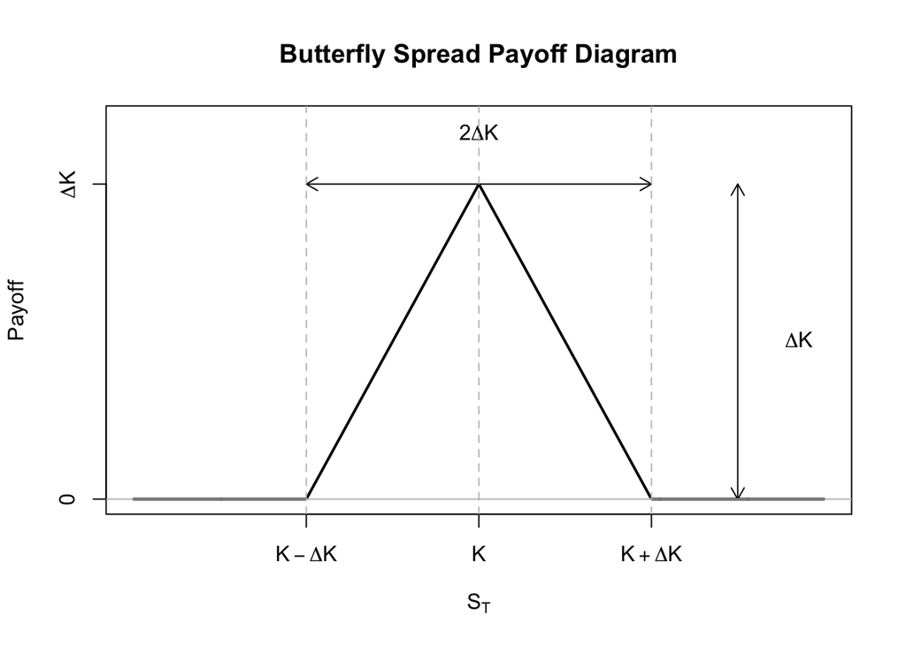

As we can see from the payoff diagram,
$$B_0 \approx e^{-rT}\mathbb{Q}(K-\Delta K\leq S_T\leq K+\Delta K)\cdot \Delta K/2$$

and since $\Delta K$ is small, around the spike we have $g(S_T)=g(K)$:
$$\begin{align*}
\mathbb{Q}\left(S_T\in(K-\Delta K, K+\Delta K)\right)& \approx g(S_T)\cdot 2\Delta K\\
&\approx g(K)\cdot 2\Delta K
\end{align*}$$
So that
$$\begin{align}
B_0 \approx e^{-rT}(\Delta K)^2 g(K) . \tag{2}
\end{align}$$
Alternatively, since $B_0$ is the discounted risk-neutral expectation, with the realization that $g(S_T)=g(K)$ around the spike, this expectation is just the area, which is $0.5\times 2\Delta K\times \Delta K =(\Delta K)^2$, times $g(K)$; that is to say, integrating the payoff over the risk-neutral probability distribution $g(S_T)$ gives the required expectation.

Combining (1) and (2), we get
$$\begin{align}
g(K) \approx e^{rT} \frac{C(K+\Delta K,T) - 2C(K,T) + C(K-\Delta K, T)}{(\Delta K)^2}, \tag{3}
\end{align}$$
which is the risk-neutral PDF of $S_T$ evaluated at $K$.

Moreover, as the fraction is the difference quotient of the second derivative of $C$ with respect to $\delta$, and letting $\delta\rightarrow 0$ gives
$$\begin{align}
g(K) = e^{rT}\frac{\partial^2C}{\partial K^2} \tag{4}
\end{align}$$

### Direct Computation

We can also recover the risk-neutral density $g(S,T)\equiv g(S_T)$ from the volatility surface $\sigma(K,T)$ via the calibrated price function $C(K,T)$.

First, as we have discussed above, given a risk-neutral density $g(S,T)$, the current value of a payoff $f(S,T)$ at time $T$ is just the discounted risk-neutral expectation

$$\begin{align}
V &= e^{-rT} \mathbb{E}_0^{\mathbb Q}[f(S,T)]\\ &=e^{-rT} \int_{-\infty}^{\infty} f(S,T) g(S_T)\, dS,
\end{align}$$
where $S_T$ is the asset price at time $T$.

So, for a call option with strike $K$ and maturity $T$, we have

$$\begin{align}
C(K,T) = e^{-rT} \int_{S_T=K}^{\infty} (S-K)\, g(S,T)\, dS.
\end{align}$$

Differentiating with respect to $K$, we get

$$\begin{align}
\frac{\partial C(K,T)}{\partial K} = -e^{-rT} \int_K^{\infty} g(S_T).
\end{align}$$

Differentiate [again](https://en.wikipedia.org/wiki/Leibniz_integral_rule) to get
$$\begin{align}
\frac{\partial^2 C(K,T)}{\partial K^2} = e^{-rT} g(K,T) = e^{-rT}\,g(K),
\end{align}$$
which is the same as (4).

### Conclusion

It is worth noting that we need to have fit the volatility surface smoothly and carefully in order to compute something like $g(K)$ in (4). However, once we have the risk neutral density $g(K)$ of $S_T$ from the implied volatility surface $\sigma(K,T)$, as we have demonstrated above, we can price any derivative $P_0$ that has a payoff $f(S_T)$ that only depends on the underlying stock price at a single and fixed time $T$. Namely,
$$\begin{align}
P_0 = e^{-rT} \mathbb{E}^{\mathbb Q}_0 [f(S_T)], \tag{5}
\end{align}$$
where, as earlier, $\mathbb{Q}$ denotes the risk-neutral measure.

However, since we do not have information about the joint distribution of the stock price at multiple times $T_1,\dots,T_n$, the volatility surface $\sigma(K,T)$ is not enough to price (path-dependent) exotic options like a [knockout put option](https://people.maths.ox.ac.uk/howison/barriers.pdf) with time $T$ payoff since such a derivative has a payoff function
$$f(S,T) = \max(0, K-S_T)\cdot \mathbf{1}_{\{\min_{0\le t\le T}(S_t)\ge B\}},$$
where $B$ represents a *barrier*, and the payoff would be zero if any of the $S_t$ falls below $B$. In this case, the marginal risk-neutral distribution we derived from the volatility surface is not enough to price this option as following the same approach would require the use of the joint $g_{0,\dots,T}(S_0,\dots,S_T)$ risk-neutral distribution.